# ISYE 6740, Fall 2020, Homework 2

## Deborah Chew

```python
import warnings
warnings.filterwarnings('ignore')
warnings.simplefilter('ignore')

from jupyterthemes import jtplot
jtplot.style(grid=False)
```

```python
import pandas as pd
import numpy as np
from scipy import linalg
from scipy.io import loadmat
from scipy.spatial import distance
import matplotlib.pyplot as plt
import seaborn as sns
from IPython.display import display

pd.set_option('display.max_columns', 8)
sns.set_color_codes("deep")
#sns.set_style("ticks")
%matplotlib inline
```

# PCA: Food consumption in European countries

The data food-consumption.csv contains 16 countries in Europe and their consumption for 20 food items, such as tea, jam, coffee, yogurt, and others. We will perform principal component analysis to explore the data. In this question, please implement PCA by writing your own code (you can use any basic packages, such as numerical linear algebra, reading data, in your file).

First, we will perform PCA analysis on the data by treating each country’s food consumption as their “feature” vectors. In other words, we will find weight vectors to combine 20 food-item consumptions for each country.

```python
fc_df = pd.read_csv('food-consumption.csv')

fc_df.head()
```

|  | Country | Real coffee | Instant coffee | Tea | ... | Margarine | Olive oil | Yoghurt | Crisp bread |
| --- | --- | --- | --- | --- | --- | --- | --- | --- | --- |
| 0 | Germany | 90 | 49 | 88 | ... | 85 | 74 | 30 | 26 |
| 1 | Italy | 82 | 10 | 60 | ... | 24 | 94 | 5 | 18 |
| 2 | France | 88 | 42 | 63 | ... | 47 | 36 | 57 | 3 |
| 3 | Holland | 96 | 62 | 98 | ... | 97 | 13 | 53 | 15 |
| 4 | Belgium | 94 | 38 | 48 | ... | 80 | 83 | 20 | 5 |

5 rows × 21 columns

Q1. For this problem of performing PCA on countries by treating each country’s food consumption as their “feature” vectors, explain how the data matrix is set-up in this case (e.g., the columns and the rows of the matrix correspond to what).

The columns of the matrix show food consumption and correspond to the "feature" vectors. The rows of the matrix correspond to the countries in the data.

Q2. Suppose we aim to find top k principal components. Write down the mathematical optimization problem for solving this problem (i.e., PCA optimization problem). Show why the first principal component is obtained by using a weight vector corresponding to the eigenvectors associated with the largest eigenvalue. Explain how to find the rest of the principal components.

Given $m$ points in a space with $d$ dimensions, PCA tries to reduce the data to a $k$-dimensional subspace.

```python
def plot_weights(w_k):

    fig = plt.figure(figsize=(16,12))

    ax1 = fig.add_subplot(221)
    ax1.stem(w_k.T[0], basefmt='r',
             use_line_collection=True)
    plt.xticks(range(len(w_k.T[0])), np.arange(1,len(w_k.T[0])+1))

    sns.despine()

    ax1.set_title("Weight Vector $w_1$")

    ax2 = fig.add_subplot(222)
    ax2.stem(w_k.T[1], basefmt='r',
             use_line_collection=True)
    plt.xticks(range(len(w_k.T[1])), np.arange(1,len(w_k.T[1])+1))

    sns.despine()

    ax2.set_title("Weight Vector $w_2$")

def plot_items(Z, labels, size, grps=None):

    plt.figure(figsize=size)
    sc = sns.scatterplot(x=Z["PC1"], y=Z["PC2"],
                         hue=grps, s=120)

    sns.despine(offset=20)

    y_offset = np.ptp(Z["PC2"]) * 0.025
    x_offset = np.ptp(Z["PC1"]) * 0.02

    for i in range(len(labels)):
        sc.text(Z["PC1"][i]+x_offset, Z["PC2"][i]-y_offset,
                labels[i], horizontalalignment="right",
                verticalalignment='center_baseline',
                size=13, color='DimGray')
```

```python
def getPCA(X, K=2, norm=False):

    m, n = X.shape

    mu = np.mean(X, axis=0)

    if norm is True:
        # normalise data
        X_norm = (X-mu)/np.std(X, axis=0)

    else:
        X_norm = X-mu

    C = (X_norm.T @ X_norm)/m

    # eigenvalue decomposition
    lmbda, w = linalg.eig(C)

    # sort eigenvalues in descending order
    indices = lmbda.argsort()[::-1]
    lmbda = lmbda[indices]
    w = w[:, indices]

    # find K eigenvectors with largest eigenvalues
    w_k = w[:, 0:K]
    lmbda_k = lmbda[0:K]

    # get reduced representation
    Z = X_norm @ w_k
    Z = Z/np.sqrt(lmbda_k)

    return np.real(w_k), np.real(lmbda_k), np.real(Z)
```

Q3. Now assume k = 2, i.e., we will find the first two principal components for each data point. Find the weight vectors $w_1$ and $w_2$ to extract these two principal components. Plot these two weight vectors, respectively. Explain if you find any interesting patterns in the weight vectors.

```python
K=2

data = fc_df.copy()
data.set_index('Country', inplace=True)

X = data.to_numpy()
w_k, lmbda_k, Z = getPCA(X, K)
```

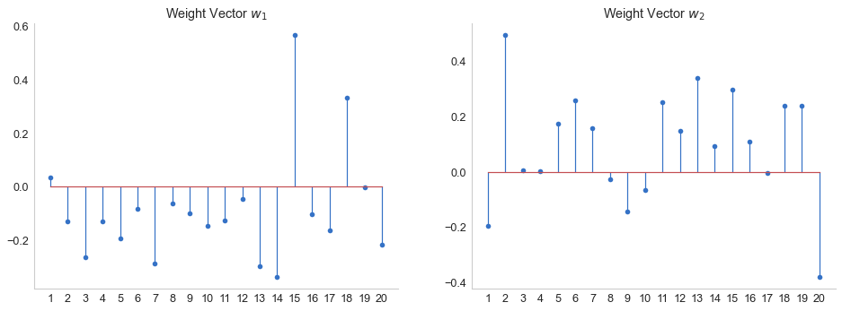

```python
plot_weights(w_k)
```

```python
print(data.columns[[14, 17]])
print(data.columns[[6, 12, 13]])
```

```
Index(['Garlic', 'Olive oil'], dtype='object')
Index(['Tin soup', 'Tinned fruit', 'Jam'], dtype='object')
```

We can conclude that consumption of garlic and olive oil account for a large amount of the variance in $w_1$. Consumption of tinned fruit and jam also contributes, but to a lesser degree.

In the plot for $w_2$, the 2nd and 20th weights have the largest absolute values, but the 2nd weight is positive while the 20th weight is negative. These values correspond to the 2nd and 20th columns of the matrix, i.e. the columns at index 1 and 19. Other fairly large weights are the 6th, 11th, 13th and 15th:

```python
print(data.columns[[1, 19]])
print(data.columns[[5, 10, 12, 14]])
```

```
Index(['Instant coffee', 'Crisp bread'], dtype='object')
Index(['Powder soup', 'Apples', 'Tinned fruit', 'Garlic'], dtype='object')
```

Consumption of instant coffee and crisp bread contribute to much of the variance. Consumption of powder soup, apples, tinned fruit and garlic also contribute but to a lesser degree.

Q4. Now extract the first two principal components for each data point (thus, this means we will represent each data point using a two-dimensional vector). Draw a scatter plot of two-dimensional representations of the countries using their two principal components. Mark the countries on the lot (you can do this by hand if you want). Please explain any pattern you observe in the scatter plot.

To better visualise the country groups, wikipedia$^{1,2,3}$ was referenced to divide the given countries into the parts of Europe they are typically considered to belong to.

```python
def split_areas(x):
    area_list = []

    area_dict = {'Northern Europe': ['Denmark','Finland',
                                     'Norway','Sweden'],
                 'Western Europe': ['Austria','Belgium',
                                    'France','Germany',
                                    'Ireland','Luxembourg',
                                    'Holland','Switzerland',
                                    'England'],
                 'Southern Europe': ['Italy','Portugal',
                                     'Spain']}

    for k in area_dict:
        if x.name in area_dict[k]:
            return k
```

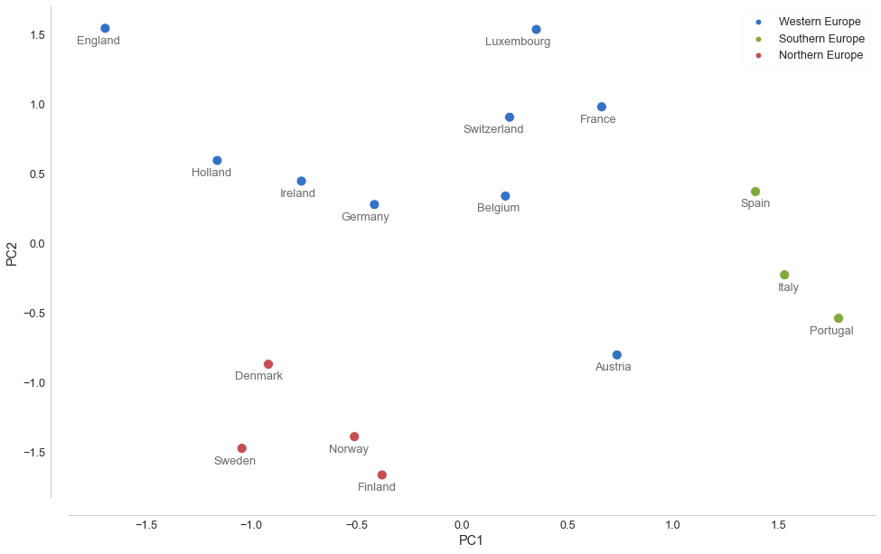

```python
pca_df = pd.DataFrame(Z, index=data.index.to_numpy(),
                      columns=['PC{}'.format(i+1) for i in range(K)])

pca_df['Area'] = pca_df.apply(split_areas, axis=1)

plot_items(pca_df, pca_df.index.to_list(),
           (16,10), pca_df['Area'].to_list())
```

PCA separates the countries into the correct areas of Europe quite distinctly.

The Southern European countries have high positive loadings on PC1. As mentioned earlier, high consumption of garlic and olive oil contributes to most of the variance in PC1. We can thus reasonably conclude that people in Southern Europe consume a lot of garlic and olive oil.

The Northern European countries have moderate to high negative loadings on PC1 and PC2. This seems to indicate that people in Northern Europe don't consume much garlic and olive oil. Looking at the stem plots for $w_1$ and $w_2$, it seems that they consume a lot of crisp bread and moderate amounts of tinned soup, tinned fruit and jam.

With the exception of Austria, the Western European countries have moderate to high positive loadings on PC2. Except for Luxembourg, France, Belgium, Switzerland and Austria, they also have negative loadings on PC1. This seems to indicate that diets in Western Europe are varied, with those closer to Southern Europe having diets more similar to Southern European countries (i.e. more consumption of garlic and olive oil) and those closer to Northern Europe having diets more similar to Northern European countries (i.e. little consumption of garlic and olive oil). The obvious point of difference between Northern and Western Europe is the loading on PC2. The largest positive value of $w_2$ corresponds to consumption of instant coffee. This seems to indicate that Western European countries with high positive loadings (i.e. England and Luxembourg) consume a lot of instant coffee.

Now, we will perform PCA analysis on the data by treating country consumptions as “feature” vectors for each food item. In other words, we will now find weight vectors to combine country consumptions for each food item to perform PCA another way.

Q5. Project data to obtain their two principle components (thus, again each data point – for each food item – can be represented using a two-dimensional vector). Draw a scatter plot of food items. Mark the food items on the plot. Please explain any pattern you observe in the scatter plot.

```python
dataT = fc_df.copy()
dataT.set_axis(dataT.pop('Country'), axis='index', inplace=True)
dataT = dataT.T

XT = dataT.to_numpy()
w_kT, lmbda_kT, ZT = getPCA(XT, 2)

pcaT_df = pd.DataFrame(ZT, index=dataT.index,
                      columns=['PC{}'.format(i+1) for i in range(K)])

# # show first 4 variables
# #display(pcaT_df.head())

# plot_weights(w_kT)
```

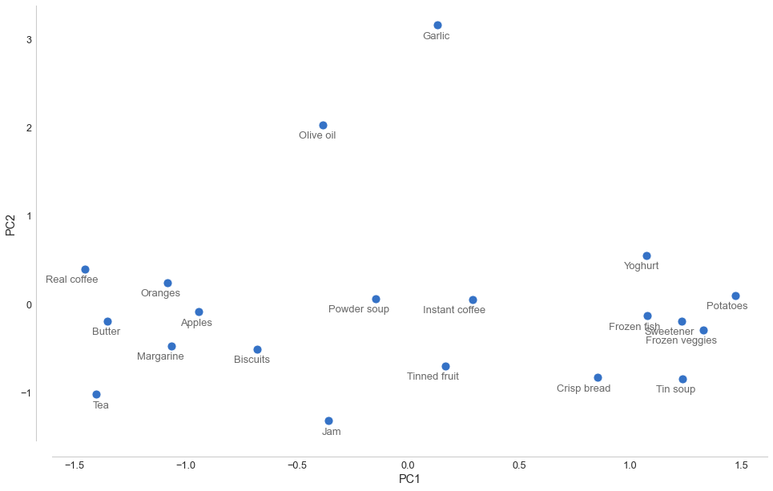

```python
plot_items(pcaT_df, pcaT_df.index.to_list(), (16,10))
```

Once again, olive oil and garlic seem to go together, being the only two food types with high positive loadings on PC2. The other food types have zero or low negative loadings on PC2 and are distributed across PC1. The food types with negative loadings on PC1 seem to be part of the stereotypical "continental breakfast", which according to wikipedia$^4$, usually includes coffee, jam, fruit, and baked goods such as bread and pastries.

Most of the food types with positive loadings on PC1 seem to be more substantial fare. These include staple foods like potatoes and bread, and frozen or pre-made foods.

# Order of faces using ISOMAP

This question aims to reproduce the ISOMAP algorithm results in the original paper for ISOMAP, J.B. Tenenbaum, V. de Silva, and J.C. Langford, Science 290 (2000) 2319-2323 that we have also seen in the lecture as an exercise.

The file isomap.mat (or isomap.dat) contains 698 images, corresponding to different poses of the same face. Each image is given as a 64 × 64 luminosity map, hence represented as a vector in $\mathbb{R}^{4096}$. This vector is stored as a row in the file.

In this question, you are expected to implement the ISOMAP algorithm by coding it up yourself. Choose the Euclidean distance (i.e., in this case, a distance in $\mathbb{R}^{4096}$) to construct the nearest neighbor graph—vertices corresponding to the images. Construct a similarity graph with vertices corresponding to the images, and tune the threshold $\epsilon$ so that each node has at least 100 neighbors (this approach corresponds to the so-called $\epsilon$-Isomap).

```python
from scipy.sparse.csgraph import dijkstra

mat = loadmat('isomap.mat')

im_df = pd.DataFrame(mat['images']).T

# Rotate the pictures
for idx in im_df.index:
    im_df.loc[idx] = im_df.loc[idx].values.reshape(64, 64).T.reshape(-1)

im_df.head()
```

|  | 0 | 1 | 2 | 3 | ... | 4092 | 4093 | 4094 | 4095 |
| --- | --- | --- | --- | --- | --- | --- | --- | --- | --- |
| 0 | 0.016176 | 0.000000 | 0.000000 | 0.000000 | ... | 0.0 | 0.0 | 0.0 | 0.0 |
| 1 | 0.016176 | 0.000000 | 0.000000 | 0.000000 | ... | 0.0 | 0.0 | 0.0 | 0.0 |
| 2 | 0.016176 | 0.000000 | 0.000000 | 0.000000 | ... | 0.0 | 0.0 | 0.0 | 0.0 |
| 3 | 0.016176 | 0.110754 | 0.384988 | 0.510034 | ... | 0.0 | 0.0 | 0.0 | 0.0 |
| 4 | 0.016176 | 0.000000 | 0.000000 | 0.000000 | ... | 0.0 | 0.0 | 0.0 | 0.0 |

5 rows × 4096 columns

[figure not shown]

```python
fig, ax = plt.subplots(6, 6, figsize=(6,6))

plt.setp(plt.gcf().get_axes(), xticks=[], yticks=[])

# 36 random pictures
for i in range(6):
    for j in range(6):
        n_im = np.random.randint(0, len(im_df))
        img = im_df.iloc[n_im, :].values.reshape(64,64)
        ax[i][j].imshow(img, aspect='auto', cmap=plt.cm.gray,
                        interpolation='nearest', zorder=100000)
```

```python
def getKNN(A, nn):

    N, M = A.shape

    W = np.zeros((N, N))

    for i in range(N):
        r_ix = np.setdiff1d(np.argsort(A[i]), [i],
                            assume_unique=True)
        r_ix = r_ix[:nn]
        W[i, r_ix] = A[i, r_ix]

    return W

def getEpsNN(A, nn, eps):

    N, M = A.shape

    W = np.zeros((N, N))

    for i in range(N):
        poss_nn = (A[i] <= A[i].mean()*eps).nonzero()
        nn_ix = np.setdiff1d(poss_nn, [i], assume_unique=True)

        # increase eps until number of possible neighbours = nn
        if nn_ix.shape[0] < nn:
            return getEpsNN(A, nn, eps+0.0005)

        W[i, nn_ix] = A[i, nn_ix]

    return W

def getIsomap(A, nn=100, K=2, method='epsNN'):

    N, M = A.shape

    if method is 'epsNN':
        # get weighted graph using epsilon threshold method
        W = getEpsNN(A, nn, 0.8)
    else:
        W = getKNN(A, nn)

    # get shortest distances
    D = dijkstra(W, directed=False)

    I = np.identity(N)
    ones = np.ones(N)
    H = I - ((1/N)*ones.T*ones)

    C = -0.5*(H @ (D**2) @ H)

    # eigenvalue decomposition
    lmbda, w = linalg.eigh(C)

    indices = lmbda.argsort()[::-1]
    lmbda = lmbda[indices]
    w = w[:, indices]

    # find K eigenvectors with largest eigenvalues
    w_k = w[:, 0:K]
    lmbda_k = lmbda[0:K]

    # get reduced representation
    Z = (np.sqrt(np.diag(lmbda_k)) @ w_k.T).T

    return w_k, lmbda_k, Z
```

```python
def plotImages(isomap_df, im_df):

    x_size = (max(isomap_df['PC1']) - min(isomap_df['PC1'])) * 0.05
    y_size = (max(isomap_df['PC2']) - min(isomap_df['PC2'])) * 0.05

    fig = plt.figure(figsize=(14,12))
    ax = fig.add_subplot(111)

    for i in np.linspace(300, 600, 30, dtype='int64'):

        x0 = isomap_df.loc[i, 'PC1'] - (x_size/2)
        y0 = isomap_df.loc[i, 'PC2'] - (y_size/2)
        x1 = isomap_df.loc[i, 'PC1'] + (x_size/2)
        y1 = isomap_df.loc[i, 'PC2'] + (y_size/2)

        img = im_df.iloc[i, :].values.reshape(64,64)
        ax.imshow(img, aspect='auto', cmap=plt.cm.gray,
                interpolation='nearest', zorder=100000,
                extent=(x0, x1, y0, y1))

    sns.scatterplot(x=isomap_df['PC1'], y=isomap_df['PC2'], alpha=0.7)

    sns.despine()
```

```python
K=2
nn=100

X_im = im_df.to_numpy()

A_euc = distance.cdist(X_im, X_im, "euclidean")
```

a) Visualize the similarity graph.

```python
import networkx as nx
import pydot as pydot

W = getEpsNN(A_euc, 100, 0.8)
G = nx.from_numpy_matrix(W)
```

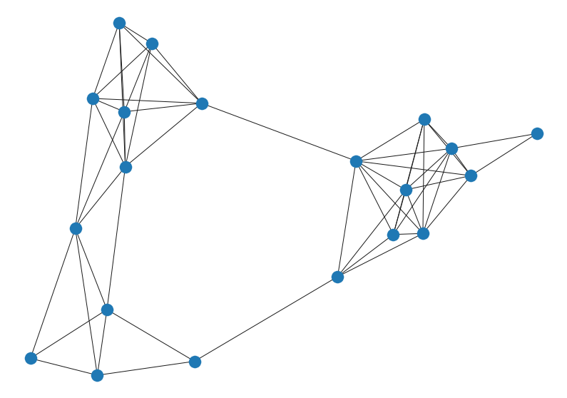

```python
fig = plt.figure(figsize=(14,10))

nodes = [i for i in range(20)]
subG = G.subgraph(nodes).copy()
edges = nx.convert.to_edgelist(subG, nodes)
posG = nx.spring_layout(subG)

## optional: superimpose pictures over nodes
# ax = fig.add_subplot(111)

# for i in nodes:
#     x0 = posG[i][0] - 0.03
#     x1 = posG[i][0] + 0.03
#     y0 = posG[i][1] - 0.03
#     y1 = posG[i][1] + 0.03
#     img = im_df.iloc[i, :].values.reshape(64,64)
#     ax.imshow(img, aspect='auto', cmap=plt.cm.gray,
#                 interpolation='nearest', zorder=100000,
#                 extent=(x0, x1, y0, y1))

nx.draw_networkx(subG, pos=posG, nodelist=nodes,
                 edgelist=edges, nodesize=20,
                 with_labels=False, scale=None)

sns.despine(left=True, bottom=True)
```

b) Implement the ISOMAP algorithm yourself to obtain a k = 2-dimensional embedding. This means, each picture is represented by a two-dimensional vector (Z in the lecture), which we called “embedding” of pictures. Plot the embeddings using a scatter plot, similar to the plots in lecture slides. Find a few images in the embedding space and show what these images look like. Comment on do you see any visual similarity among them and their arrangement, similar to what you seen in the paper?

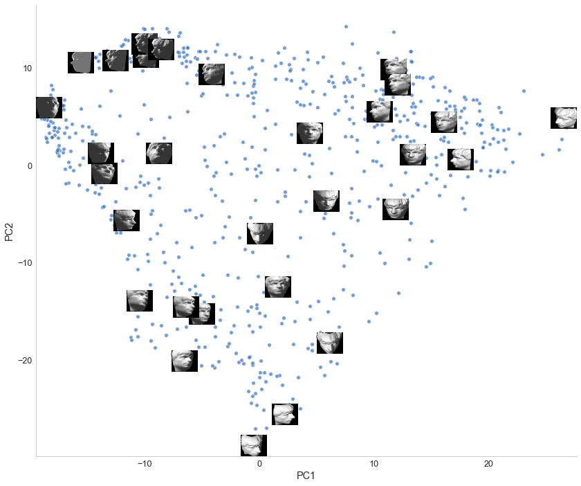

```python
w_euc, lmbda_euc, Z_euc = getIsomap(A_euc, nn, K)

isomap_df_euc = pd.DataFrame(Z_euc, index=im_df.index,
                             columns=['PC{}'.format(i+1) for i in range(K)])

plotImages(isomap_df_euc, im_df)
```

The picture clusters appear to form distinct groups. The pictures with the front view of the face cluster together in the middle of the scatter plot. The pictures with the faces looking right lie along the upper edge of the scatterplot, with the ones on the far left show the face angled up and the one on the far right angled down. The pictures with the face looking left are on the left side of the scatter plot, following the diagonal edge, with the ones at the bottom showing the face angled down.

c) Now choose $\ell_1$ distance (or Manhattan distance) between images (recall the definition from “Clustering” lecture)). Repeat the steps above. Use $\epsilon$-ISOMAP to obtain a k = 2 dimensional embedding. Present a plot of this embedding. Do you see any difference by choosing a different similarity measure by comparing results in Part (b) and Part (c)?

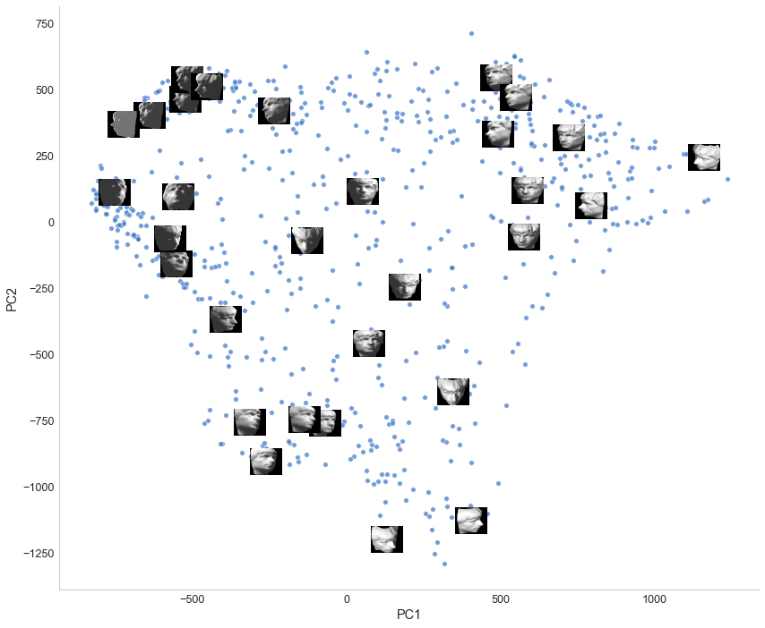

```python
A_mnh = distance.cdist(X_im, X_im, "cityblock")

w_mnh, lmbda_mnh, Z_mnh = getIsomap(A_mnh, nn, K)

isomap_df_mnh = pd.DataFrame(Z_mnh, index=im_df.index,
                             columns=['PC{}'.format(i+1) for i in range(K)])

plotImages(isomap_df_mnh, im_df)
```

The results when using Manhattan distance as the similarity measure are slightly different from the previous results using Euclidean distance. The pictures showing a left or right side view appear to form tighter cluster groups. However the front view images are less distinctly separated from the profile view images, although they continue to cluster in the middle of the plot.

d) Perform PCA (you can now use your implementation written in Question 1) on the images and project them into the top 2 principal components. Again show them on a scatter plot. Explain whether or you see a more meaningful projection using ISOMAP than PCA.

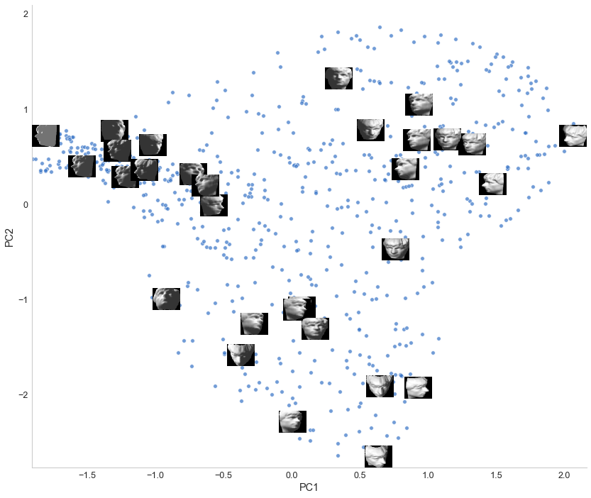

```python
w_pca, lmbda_pca, Z_pca = getPCA(X_im, 2)

pca_df = pd.DataFrame(Z_pca, index=im_df.index,
                      columns=['PC{}'.format(i+1) for i in range(K)])

plotImages(pca_df, im_df)
```

While PCA does show some picture clusters that have a visible element of similarity (e.g. the cluster at the bottom of the plot shows pictures angled down and/or facing right), these appear to be based more on the amount of light and shadow in the images. The images with faces with deep shadows are clustered at the top left corner of the plot and those with less shadow and brighter lighting are clustered at the bottom or the far right of the plot. PCA does not separate the images into categories more meaningful than the degree of light and shadow.

The ISOMAP projection is much clearer and more meaningful, because we can clearly see the images separated into distinct groups depending on the direction the face is looking and whether it is angled up or down.

## References

1.https://en.wikipedia.org/wiki/Northern_Europe  
2.https://en.wikipedia.org/wiki/Western_Europe  
3.https://en.wikipedia.org/wiki/Southern_Europe  
4.https://en.wikipedia.org/wiki/Breakfast#Europe